Food-web theory · work in progress · October 2026

# Flexible diets, fragile routes

Predators that switch between prey help complex food webs keep their species. The reason is simple: an adaptive predator sets a *price* on each prey, a density below which that prey is no longer worth eating, so it never eats a prey to extinction. From this we can predict how many species survive without running a simulation, and the speed of switching turns out to matter in a different way from what has been assumed.

Lachlan Burton · a plain-language summary of work in progress on adaptive food webs. Results are preliminary. Back to projects

## The question

Are complex ecosystems more stable than simple ones, or less? Random-network models, starting with May (1972), predict less: adding species and feeding links makes a community less likely to be stable. Yet real ecosystems are very complex, and they persist.

Kondoh (2003) proposed an explanation. Real predators do not eat from a fixed menu; they shift their foraging towards whichever prey currently gives the best return. In his simulations, when predators adapted in this way, more complex food webs were more likely to keep all their species.

[figure not shown]

**How a predator adapts.** Line width shows how the predator divides its foraging effort. An adaptive predator moves effort towards the prey with the best return, here the common one. Eating that prey down lowers its return, so effort spreads until every prey in the diet returns the same. Shoppers spread across checkout queues by the same logic, until the waits are equal. The rare prey is left alone.

## What we did

We built hundreds of random food webs on a computer, with 12 to 500 species, and ran each one two ways: predators that split their effort evenly and never change, and predators that adapt. Then we looked at where each community ends up, and how it gets there.

We also ran them with and without an *extinction line*, a rule that removes any species whose numbers drop below a tiny value. Kondoh used one, as do most food-web models. Without the line, a species is counted as lost only if its numbers keep falling towards zero and it cannot grow back from small numbers.

We used two kinds of web. In Kondoh's setup every species can grow on its own. In the second, half the species need prey to survive, as most predators do.

## The model in two equations

The model is Kondoh's. Each species *i* has a population density *N<sub>i</sub>*, which changes as

dN<sub>i</sub>/dt = N<sub>i</sub> ( r<sub>i</sub> − s<sub>i</sub>N<sub>i</sub> + e Σ<sub>j</sub> a<sub>ij</sub> f<sub>ij</sub> N<sub>j</sub> − Σ<sub>k</sub> a<sub>ki</sub> f<sub>ki</sub> N<sub>k</sub> )

Read the bracket left to right. A species grows at its own rate *r<sub>i</sub>*, is limited by crowding (*−s<sub>i</sub>N<sub>i</sub>*), gains from what it eats and loses to what eats it. Here *r<sub>i</sub>* is the species' net growth rate on its own (births minus deaths), and *s<sub>i</sub>* sets how strongly it limits itself, so on its own it settles at *r<sub>i</sub>*/*s<sub>i</sub>*. In Kondoh's setup every *r<sub>i</sub>* is positive and *s<sub>i</sub>* = 1. In the gain term, *f<sub>ij</sub>* is the rate at which predator *i* captures prey *j*, *a<sub>ij</sub>* is the share of its foraging effort spent on *j*, and *e* is the fraction of eaten food converted into new growth. The loss term is the same interaction seen from the prey's side, summed over its predators *k*.

The second equation is the adaptation rule:

da<sub>ij</sub>/dt = G a<sub>ij</sub> ( e f<sub>ij</sub> N<sub>j</sub> − Σ<sub>l</sub> a<sub>il</sub> e f<sub>il</sub> N<sub>l</sub> )

Here *e f<sub>ij</sub> N<sub>j</sub>* is the return per unit of effort that predator *i* gets from prey *j*, and the sum after it is the predator's average return over its whole diet. Effort on a prey grows if it returns more than average and shrinks if it returns less, at a rate set by *G*. This is the replicator equation of evolutionary game theory (Hofbauer & Sigmund 1998), applied to each predator's diet. A fixed diet is *a<sub>ij</sub>* = 1/*k<sub>i</sub>*, where *k<sub>i</sub>* is the number of prey species that *i* can eat.

Proven at e = 1; tested in simulation below that

## A single end state

An end state is a state in which every species present has stopped changing, no predator can raise its intake by moving effort, and no absent species can invade. Here a species can *invade* if a few of its individuals, added to the web, would increase in number. This is a test of the end state, not a model of species arriving from elsewhere. Start an adaptive food web from any populations, any diets and any adaptation speed, and, in the settings we study, it reaches the same end state: the same species, at the same densities. The end state is set by the web itself (which species it contains, who can eat whom, and their growth and feeding rates), not by its history.

In the special case where predators convert all the food they eat into growth (*e* = 1), we can prove this. We found a Lyapunov function: a quantity that only ever decreases as the community changes, so the system behaves like a ball rolling into a single valley. The construction extends one that Boukal and Křivan (1999) used for small predator–prey models.

When predators convert less than all they eat (*e* < 1), the same calculation leaves one term that can push the wrong way: a predator above its end-state number while its prey is below, the classic predator–prey swing. Crowding damps that swing. If crowding is strong enough compared with feeding, the end state is again unique and every run reaches it; we can prove that. In practice our condition is stricter than needed. We tested 360 webs of 50 and 100 species, each from several starts. With feeding rates up to 1, as in Kondoh's setup, every web reached a single end state, including 40 webs where our condition fails. With feeding rates up to 3 and low efficiency (*e* = 0.15), 23 of 60 webs never settled: some kept cycling, and in others species kept falling to vanishingly low numbers and coming back. We never saw a web settle in two different end states, but they exist: we found a four-species web with two.

### The Lyapunov function

V = Σ<sub>i</sub> ( N<sub>i</sub> − N<sub>i</sub>* ln N<sub>i</sub> ) + (1/G) Σ<sub>i</sub> N<sub>i</sub>* Σ<sub>j</sub> a<sub>ij</sub>* ln (a<sub>ij</sub>* / a<sub>ij</sub>)

Starred values are those at the end state. The first sum is the standard Lyapunov function for Lotka–Volterra communities (Volterra 1931; Goh 1977); it is smallest when every population is at its end value. The second sum is the Kullback–Leibler divergence between each predator's diet and its end-state diet, the standard Lyapunov function for replicator dynamics (Hofbauer & Sigmund 1998), weighted by the predator's end-state density and by 1/*G*. When *e* = 1, what a predator gains in each interaction exactly matches what its prey loses, the cross terms cancel, and *V* can only decrease. Every trajectory therefore ends at the same point.

**What "set by the web" means.** Height stands for a quantity that always goes down. Left: one valley, so every start ends at the same bottom. That's what we see for adaptive webs. Right: two valleys, where the same web can end up in different communities depending on where it starts. This is only a sketch; the real system has one dimension per species.

Solid for Kondoh's setup

## Flexible diets keep more species

In Kondoh's setup, adaptive webs usually kept every species, while fixed-diet webs lost about 5 to 20 percent. The few species that adaptive webs do lose are prey of predators with no alternative food, which cannot switch away.

When half the species need prey, fixed-diet webs keep about half of their species however many links they have. Adaptive webs keep 56 percent when each species can eat about 2 others, rising to 71 percent when it can eat 20 or more.

The effect grows with web size. Kondoh studied webs of up to 20 species. In webs of 50 species with fast-adapting predators, between 81 and 96 percent of webs kept every single species when at least 30 percent of possible links were present, more than in webs of 20.

survives, fixed dietssurvives, adaptive dietslost

**Roll call for one 20-species web** at its end state, with no extinction line. Fixed diets lose 4 species; adaptive diets keep all 20. Species 18 (ringed) is one of the losses under fixed diets. With adaptive diets it survives, but only just (next figure).

Exact at every end state, checked on 640 webs

## Adaptive predators don't wipe out their prey

Why do adaptive webs keep more species? Look at what happens to a prey as it becomes rare.

With a fixed diet, a predator keeps the same share of its effort on a prey however rare it gets. Each prey individual faces the same risk of being eaten, so if its predators are common, the prey keeps declining all the way to zero.

An adaptive predator only feeds on a prey while it pays at least as well as its other options. As the prey becomes rare it pays less, and the predator moves its effort elsewhere. The pressure on a rare prey therefore falls away, and a prey that can grow on its own grows back from any small number.

At the end state this becomes an exact rule. Each prey that is eaten settles at a *price*: the density at which it pays a predator exactly as well as that predator's best food. With several predators, the lowest of these prices applies:

N<sub>j</sub> = min ( D<sub>j</sub>, min<sub>k</sub> π<sub>k</sub> / f<sub>kj</sub> )

Here *D<sub>j</sub>* is the density the prey would reach with no predators, *π<sub>k</sub>* is the return per unit of effort that predator *k* gets at the end state, and *f<sub>kj</sub>* is how efficiently it catches *j*. The price is above zero whenever the predator has other food, so an adaptive predator never drives a prey extinct. Species are lost only by starving (a species that needs prey and cannot get enough), or as prey of a predator with nothing else to eat. In our simulated end states the rule holds to within one part in a billion for the typical species.

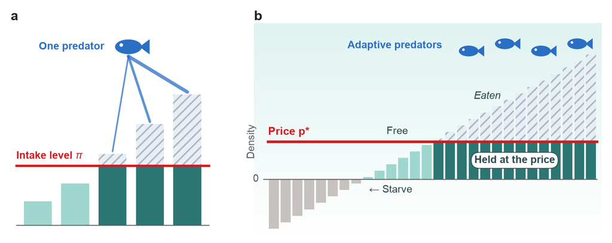

New, preliminary

## Speed changes the route, not the destination

If the end state does not depend on speed, what does speed change? The route. Slow adapters keep feeding on a declining prey for too long, so it crashes to very low numbers before predators move on, and only then recovers. The slower the adaptation, the deeper the crash. Fixed-diet webs show no such crashes: species that survive never fall far, and those that are lost decline to extinction.

The Lyapunov function *V* also limits how deep a crash can be. Since *V* never increases, the density of a surviving species has a lower bound set by the initial value of *V*. The diet term of *V* is divided by *G*, so slow adaptation gives a large initial *V* and a weak bound. The bound is far from tight, but it has the observed form: crash depth, in powers of ten, grows roughly in proportion to 1/*G*.

fixed dietsfast adaptationmediumslowKondoh's extinction line

**One species, four runs.** Density of species 18 over time; all four runs start from the same state. The scale is logarithmic, with each gridline a factor of 10<sup>100</sup> lower. With fixed diets the species goes extinct. With adaptive diets it survives every time, but under slow adaptation it first falls to about one part in 10<sup>275</sup> of its usual density. Hover to read values.

New, preliminary

## Adaptation speed matters through the extinction line

A real population that fell to one part in 10<sup>275</sup> would be extinct. Models represent this with an extinction line, and that is where adaptation speed matters. We reran Kondoh's setup exactly. With his extinction line, the share of webs that kept every species rose steeply with adaptation speed, as he reported. Without it, species are counted only at the end of the run (numbers above one part in 10<sup>13</sup> at time 100 000). Every adaptive web then kept every species at every speed. Fixed-diet webs still lost species, because their rare species keep being eaten and decline towards zero. Adaptive predators move away from a prey once it becomes rare, so a rare prey under adaptive diets recovers.

So Kondoh's measure and the end state answer different questions. The extinction line asks whether every species survives the whole journey; the end state says where the journey finishes. The end state is the same either way.

**Kondoh's setup: 12 random webs of 20 species.** Each square is one web, filled if every species in it survived. Left: species are removed for good below one part in 10<sup>13</sup>, as in Kondoh's study. Right: no extinction line; species are counted only at the end of the run. Fixed-diet webs lose species either way, because a rare prey with a fixed-diet predator keeps declining.

Known since 1991

## Adapted diets get narrow

Each predator could eat many prey, but at the end state it eats only one or two. In total, fewer links stay in use than twice the number of species. Matsuda and Namba (1991) proved this for coevolutionarily stable communities. It matters for theory, because it keeps the network of feeding ties sparse.

The argument is short. If a predator divides its effort between two prey, they must give it the same return:

f<sub>ij</sub> N<sub>j</sub> = f<sub>il</sub> N<sub>l</sub>

Each such tie fixes the ratio of two prey densities. Count every species twice, once in its role as a predator and once in its role as prey, and draw each link in use between a predator role and a prey role. A loop in that network of roles would constrain the same ratio along two different routes, which requires an exact coincidence among the feeding rates. So the network of roles has no loops, and a network without loops has fewer links than nodes: here, fewer than twice the number of species.

That is a statement about roles, not species. Because one species can be a predator in one tie and a prey in another, the links in use can still form loops among species, including feeding loops: in the web below, 13 eats 1, 15 eats 13, 14 eats 15, 8 eats 14, 5 eats 8 and 1 eats 5. Kondoh's random webs allow such loops, which are rare in real food webs. His second kind of web, the cascade web, has none: species are ranked and each can eat only species below it. Adaptive diets help there in the same way. In cascade webs of 20 species with fast adaptation, the share of webs that kept every species rose from 25 to 86 percent as more links were added, against about 3 percent with fixed diets.

**The same 20-species web.** Faint lines are all the possible feeding links. Blue arrows are the ones still in use at the end, pointing from prey to predator. Hover a species to see its links.

New: matches simulations with nothing fitted

## Predicting the end state without simulating it

Because a web that settles has one end state, set by the web itself, it should be possible to calculate it from a few summary statistics. We built such a calculation, using the *cavity method* from the physics of disordered systems. It has been used before for food webs whose interactions are fixed (Bunin 2017; Barbier et al. 2018). Adaptive diets needed a new version.

The idea is to solve one species at a time, as if it had just been added to a web that has already settled. Its neighbours tell it two things. A predator tells it how hard it would eat this prey at each possible prey density. A prey tells it how much eating it would take to hold that prey at each density, allowing for the prey's other predators easing off. The species then settles its own density and diet, and passes the same kind of message on. Repeated over a large pool, this gives the whole distribution of end states.

Nothing in the calculation is fitted to the simulations. Across 640 simulated webs of 50 to 500 species, it predicts the share of species that survive to within 2 percentage points, average densities and returns to within about 4 percent, and the full spread of densities across species. It predicts the fixed-diet webs as well, so the gain from adaptation can be calculated too.

adaptive diets, simulatedadaptive diets, calculatedfixed diets, simulatedfixed diets, calculatedlimit for very broad diets

**Share of species that survive, against how many prey each species could eat.** Dots are averages over simulated end states, lines are the calculation. Dots at 2, 5, 10 and 20 average 40 webs of 50 to 500 species; dots at 3, 4, 7, 14 and 28 average 20 webs of 500 species; the dots at 40 average 20 webs of 1000 species. With fixed diets survival stays flat as webs get more links. With adaptive diets it rises, towards the limit worked out below. Hover a dot to read values.

**Show the numbers**

New: exact in the limit, confirmed by simulation

## Complexity and stability in one line

As each species gets more possible prey, the calculation simplifies to a single equation. Every predator finds prey it catches efficiently, so all predators end up with the same return, a single price *p**. A species' density is then the lower of its density without predators, *D* = *r* + *e p**, and the price. The price is fixed by a balance: what predators eat must equal what they need. That balance reads

E [ (D − p*)<sub>+</sub> ] = ½ E [ D<sub>+</sub> ]

where E is an average over species and the subscript + means "only where positive". In words: at the end state, the biomass left standing and the biomass eaten are each half of what the species could reach without predators.

The share of species that survive then follows: a species survives if it can live on prey at the going price, *r* + *e p** > 0. When half the species need prey (growth rates spread evenly from −0.1 to 0.1) and predators convert all they eat (*e* = 1), adaptive webs keep 1/√2, about 71 percent, against 50 percent for fixed diets at any number of links. Simulated webs of 1000 species with 40 possible prey each keep 70.9 percent.

This is the end-state form of Kondoh's result: more potential feeding links mean more survivors when diets adapt. With fixed diets survival stays flat in most cases (in one case, where every species can live alone and predators convert all they eat, it creeps up a little, but stays below adaptive diets).

The "half and half" comes from two of Kondoh's choices: the fastest feeding rate equals the strength of crowding (both 1). In general the eaten share is the fastest feeding rate divided by that rate plus crowding; we checked this in simulations with feeding rates up to 0.5, where a third is eaten. A single price does not need all predators to be alike: it holds when conversion efficiencies differ between predators too.

The calculation also shows where adaptation matters most. When every species can live alone and conversion is efficient, fixed diets already keep almost everyone, and the gain is small. The gain is largest, about 29 percentage points, when about 29 percent of species need prey (exactly 1 − 1/√2 when *e* = 1).

New, preliminary

## What if predators get full?

Real predators cannot eat without limit: each catch takes handling time, so intake levels off when prey are plentiful. Does the price rule survive? At the end state, yes, exactly. A predator's total intake there equals its best return, so getting full scales everything about that predator by one fixed factor, and it still ranks its prey the same way. In simulated webs the rule held to within one part in a billion at every end state, and the calculation predicted survival as well as without handling time.

What changes is how many species survive where species need prey (fewer do, because a full predator can gain only so much), and whether webs settle at all. With strong handling times, webs where each species has few possible prey often kept cycling instead of settling, some with species crashing during the cycle, while webs with many possible prey settled every time. Saturation can stop webs with narrow diets from settling, partly through the paradox of enrichment (Rosenzweig 1971) and partly through species turnover; broad adaptive diets kept webs settling.

## What about rewiring?

Our wider project also studies *rewiring*, in which a predator that loses its prey adds a new species to its diet (Gilljam et al. 2015). Does rewiring break the one-valley picture?

Gaining and losing links is not the problem in itself. Adaptive predators already drop links, by putting no effort into them, and can take them up again later, and the web still has a single end state. The difference lies in how choices are made. Continuous adaptation keeps every option open and keeps revising. Rewiring makes a one-off choice when a trigger fires, and keeps it. The web then retains a memory of the order in which events happened, so different runs can end differently. An extinction line has the same effect: a species removed during a crash never returns.

[figure not shown]

**Where history dependence comes from.** Which prey looks best depends on exactly when the trigger fires, so runs that differ only in timing can lock in different choices and reach different end states. Our single end state is where rewiring would lead if it were continuous and reversible, which makes it a natural reference against which to measure real rewiring.

## Why it matters

- It splits Kondoh's result into two separate effects. Adaptation changes where a food web ends up: more species survive at the end, at any speed. Adaptation speed only changes how the web gets there: slow switching drives species through deep crashes on the way, and in a real population (or a model with an extinction line) those crashes are permanent losses. So whether adaptation actually saves species depends on how fast predators switch compared with how fast populations change.
- Because the end state is set by the web, it can be calculated from a few summary statistics of the web, without simulation. The calculation explains Kondoh's link between complexity and stability for the end state, and gives its size in closed form.

## References

- Barbier, M., Arnoldi, J.-F., Bunin, G. & Loreau, M. (2018). Generic assembly patterns in complex ecological communities. *PNAS* 115, 2156–2161.
- Boukal, D. S. & Křivan, V. (1999). Lyapunov functions for Lotka–Volterra predator–prey models with optimal foraging behavior. *Journal of Mathematical Biology* 39, 493–517.
- Bunin, G. (2017). Ecological communities with Lotka–Volterra dynamics. *Physical Review E* 95, 042414.
- Gilljam, D., Curtsdotter, A. & Ebenman, B. (2015). Adaptive rewiring aggravates the effects of species loss in ecosystems. *Nature Communications* 6, 8412.
- Goh, B. S. (1977). Global stability in many-species systems. *American Naturalist* 111, 135–143.
- Hofbauer, J. & Sigmund, K. (1998). *Evolutionary Games and Population Dynamics*. Cambridge University Press.
- Kondoh, M. (2003). Foraging adaptation and the relationship between food-web complexity and stability. *Science* 299, 1388–1391.
- Mézard, M. & Parisi, G. (2001). The Bethe lattice spin glass revisited. *European Physical Journal B* 20, 217–233.
- Matsuda, H. & Namba, T. (1991). Food web graph of a coevolutionarily stable community. *Ecology* 72, 267–276.
- May, R. M. (1972). Will a large complex system be stable? *Nature* 238, 413–414.
- Rosenzweig, M. L. (1971). Paradox of enrichment: destabilization of exploitation ecosystems in ecological time. *Science* 171, 385–387.
- Volterra, V. (1931). *Leçons sur la théorie mathématique de la lutte pour la vie*. Gauthier-Villars, Paris.